# Fire-Ants-Scrum

April 20, 2017

## Administrivia

- Around the Horn

## Notes From Last Scrum / Launch Workshop

- Great progress.
- New team coming together.

## Release 1.0 Progress

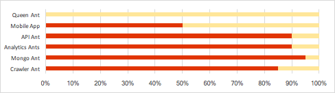

- **Queen Ant** - initiate calls to Analytics Ant and Crawler Ant
- **Mobile UI** - Navigation completed. Virtustream.
- **API Ant** - add "event" field
- **Analytics Ant** - code completed. containerize wired to db.
- **Mongo Ant** - improve security
- **Crawler Ant** - containerize

## Topics

## Summary Notes

- Discussed Machine Learning. Bee outlined Machine Learning in terms of medical diagnoses.
- Bee working on replacing StrikeFX models (subtract 1 density from another).
- Darren reports Navigation & Wiring completed. 2pm CDT webex scheduled for Mobile UI Overview
- Bat woking on Machine Learning. 3pm CDT webex scheduled for Container overview
- Dan outlined some recent React Native releases (gestures, Android GUI, etc.). Also shared some limitations regarding Virtustream Object store. Access credentials are managed via a proxy web server (i.e. nginix)
- Sweezy working to add fields to API and will send updated URL for the special students
- Queen Ant will initiate call to Analytics Ant and Crawler Ant
- Mongo Ant needs a little more security. 95%
- Crawler Ant needs to be containerized.